# Project: Investigate a Dataset (Replace this with something more specific!)

### Move Each Value in the Genre Column to its Own Row

```python
# Find movies with multiple genres
mg_df = df[df['genres'].str.contains('|')]
# Create a row for each genre for a given movie
genre_rows = mg_df['genres'].str.split('|').apply(Series, 1).stack()
# Match the indexing to the original dataframe
genre_rows.index = genre_rows.index.droplevel(-1)
# Name needed for join
genre_rows.name = 'genres'
# Replace old genres column with new column
del mg_df['genres']
mg_df = mg_df.join(genre_rows)
# Drop original multi-value rows
df.drop(mg_df.index, inplace=True)
# add in our newly separated rows
df = df.append(mg_df, ignore_index=True)
```

```python
df.head()
```

|  | budget_adj | cast | director | genres | production_companies | revenue_adj | runtime | vote_average | vote_count |
| --- | --- | --- | --- | --- | --- | --- | --- | --- | --- |
| 0 | 1.379999e+08 | Chris Pratt\|Bryce Dallas Howard\|Irrfan Khan\|Vi... | Colin Trevorrow | Action | Universal Studios\|Amblin Entertainment\|Legenda... | 1.392446e+09 | 124.0 | 6.5 | 5562 |
| 1 | 1.379999e+08 | Chris Pratt\|Bryce Dallas Howard\|Irrfan Khan\|Vi... | Colin Trevorrow | Adventure | Universal Studios\|Amblin Entertainment\|Legenda... | 1.392446e+09 | 124.0 | 6.5 | 5562 |
| 2 | 1.379999e+08 | Chris Pratt\|Bryce Dallas Howard\|Irrfan Khan\|Vi... | Colin Trevorrow | Science Fiction | Universal Studios\|Amblin Entertainment\|Legenda... | 1.392446e+09 | 124.0 | 6.5 | 5562 |
| 3 | 1.379999e+08 | Chris Pratt\|Bryce Dallas Howard\|Irrfan Khan\|Vi... | Colin Trevorrow | Thriller | Universal Studios\|Amblin Entertainment\|Legenda... | 1.392446e+09 | 124.0 | 6.5 | 5562 |
| 4 | 1.379999e+08 | Tom Hardy\|Charlize Theron\|Hugh Keays-Byrne\|Nic... | George Miller | Action | Village Roadshow Pictures\|Kennedy Miller Produ... | 3.481613e+08 | 120.0 | 7.1 | 6185 |

### Repeat Previous Action with Cast & Production Company

```python
# Find movies with multiple cast members
mg_df = df2[df2['cast'].str.contains('|')]
# Create a row for each cast member for a given movie
cast_rows = mg_df['cast'].str.split('|').apply(Series, 1).stack()
# Match the indexing to the original dataframe
cast_rows.index = cast_rows.index.droplevel(-1)
# Name needed for join
cast_rows.name = 'cast'
# Replace old cast column with new column
del mg_df['cast']
mg_df = mg_df.join(cast_rows)

# Drop original multi-value rows
df2.drop(mg_df.index, inplace=True)
# add in our newly separated rows
df2 = df2.append(mg_df, ignore_index=True)
```

```python
df2.head()
```

|  | budget_adj | cast | director | genres | production_companies | revenue_adj | runtime | vote_average | vote_count |
| --- | --- | --- | --- | --- | --- | --- | --- | --- | --- |
| 0 | 1.379999e+08 | Chris Pratt | Colin Trevorrow | Action\|Adventure\|Science Fiction\|Thriller | Universal Studios\|Amblin Entertainment\|Legenda... | 1.392446e+09 | 124.0 | 6.5 | 5562 |
| 1 | 1.379999e+08 | Bryce Dallas Howard | Colin Trevorrow | Action\|Adventure\|Science Fiction\|Thriller | Universal Studios\|Amblin Entertainment\|Legenda... | 1.392446e+09 | 124.0 | 6.5 | 5562 |
| 2 | 1.379999e+08 | Irrfan Khan | Colin Trevorrow | Action\|Adventure\|Science Fiction\|Thriller | Universal Studios\|Amblin Entertainment\|Legenda... | 1.392446e+09 | 124.0 | 6.5 | 5562 |
| 3 | 1.379999e+08 | Vincent D'Onofrio | Colin Trevorrow | Action\|Adventure\|Science Fiction\|Thriller | Universal Studios\|Amblin Entertainment\|Legenda... | 1.392446e+09 | 124.0 | 6.5 | 5562 |
| 4 | 1.379999e+08 | Nick Robinson | Colin Trevorrow | Action\|Adventure\|Science Fiction\|Thriller | Universal Studios\|Amblin Entertainment\|Legenda... | 1.392446e+09 | 124.0 | 6.5 | 5562 |

```python
# Find movies with multiple production companies
mg_df = df3[df3['production_companies'].str.contains('|')]
# Create a row for each production company for a given movie
pc_rows = mg_df['production_companies'].str.split('|').apply(Series, 1).stack()
# Match the indexing to the original dataframe
pc_rows.index = pc_rows.index.droplevel(-1)
# Name needed for join
pc_rows.name = 'production_companies'
# Replace old production companies column with new column
del mg_df['production_companies']
mg_df = mg_df.join(pc_rows)

# Drop original multi-value rows
df3.drop(mg_df.index, inplace=True)
# add in our newly separated rows
df3 = df3.append(mg_df, ignore_index=True)
```

```python
df3.head()
```

|  | budget_adj | cast | director | genres | production_companies | revenue_adj | runtime | vote_average | vote_count |
| --- | --- | --- | --- | --- | --- | --- | --- | --- | --- |
| 0 | 1.379999e+08 | Chris Pratt\|Bryce Dallas Howard\|Irrfan Khan\|Vi... | Colin Trevorrow | Action\|Adventure\|Science Fiction\|Thriller | Universal Studios | 1.392446e+09 | 124.0 | 6.5 | 5562 |
| 1 | 1.379999e+08 | Chris Pratt\|Bryce Dallas Howard\|Irrfan Khan\|Vi... | Colin Trevorrow | Action\|Adventure\|Science Fiction\|Thriller | Amblin Entertainment | 1.392446e+09 | 124.0 | 6.5 | 5562 |
| 2 | 1.379999e+08 | Chris Pratt\|Bryce Dallas Howard\|Irrfan Khan\|Vi... | Colin Trevorrow | Action\|Adventure\|Science Fiction\|Thriller | Legendary Pictures | 1.392446e+09 | 124.0 | 6.5 | 5562 |
| 3 | 1.379999e+08 | Chris Pratt\|Bryce Dallas Howard\|Irrfan Khan\|Vi... | Colin Trevorrow | Action\|Adventure\|Science Fiction\|Thriller | Fuji Television Network | 1.392446e+09 | 124.0 | 6.5 | 5562 |
| 4 | 1.379999e+08 | Chris Pratt\|Bryce Dallas Howard\|Irrfan Khan\|Vi... | Colin Trevorrow | Action\|Adventure\|Science Fiction\|Thriller | Dentsu | 1.392446e+09 | 124.0 | 6.5 | 5562 |

### Question 1: Which Genre has the Highest Mean Vote Average?

> To answer this question, I had to first find the mean vote average of each genre. In order to make sense of my results, I created a bar chart which has bars showing the mean vote average of each genre. Even after creating the bar chart however, I could only approximately guess which genre had the largest mean vote average, and to remedy this situation I made it so the value of each bar was placed next to it.

```
<Container object of 20 artists>
```

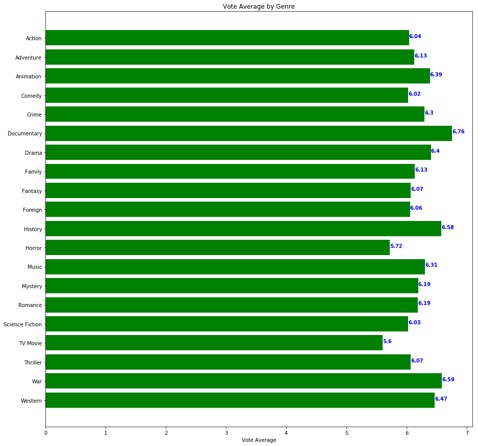

```python
# Use this, and more code cells, to explore your data. Don't forget to add
#   Markdown cells to document your observations and findings.

# Define size of figure.
fig, ax = plt.subplots(figsize=(15,15))

# Get the average vote_average for each genre
vote_average = df.groupby('genres')['vote_average'].mean()

# Find positions of y ticks
y_pos = np.arange(len(df['genres'].unique()))
# Set up Bar Chart
ax.set_yticks(y_pos)
ax.set_yticklabels(sorted(df['genres'].unique()))
ax.set_xlabel('Vote Average')
ax.set_title('Vote Average by Genre')

# Set Size of X and Y labels
plt.rc('xtick', labelsize=8)
plt.rc('ytick', labelsize=8)

# Put Values next to Each Bar
for i, v in enumerate(vote_average):
    ax.text(v, i, str(round(v,2)), color='blue', fontweight='bold')

ax.invert_yaxis()  # labels read top-to-bottom

# Draw Bar Chart
ax.barh(y_pos, vote_average, align='center', color='green', ecolor='black')
```

#### The Genre with the Highest Vote Average is Documentary

> I used the group by function to find the vote average of each unique genre in the database, and then used matplotlib's barh function to get a visualization of the results. In addition to this, I used the enumerate function, in addition to matplotlib's text function to make it so the value of each genre was displayed next to its corresponding bar

### Question 2: What are the Characteristics of Movies with High Vote Averages?

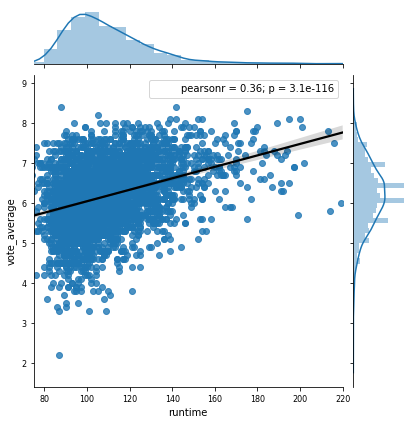

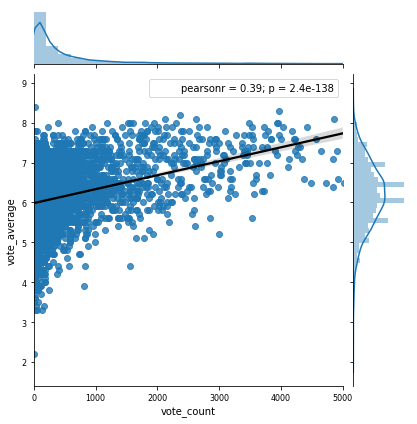

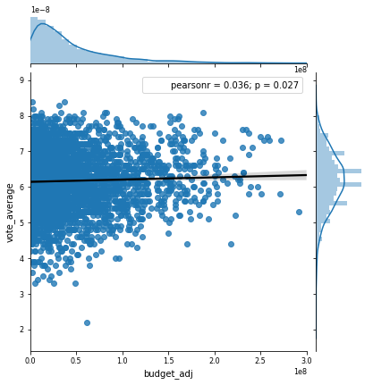

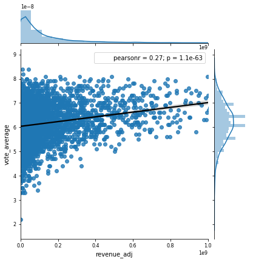

```python
# Continue to explore the data to address your additional research
#   questions. Add more headers as needed if you have more questions to
#   investigate.
display(sns.jointplot(x='runtime', y='vote_average', data=df4, kind='reg', xlim=(75,220), joint_kws={'line_kws':{'color':'black'}}))
display(sns.jointplot(x='vote_count', y='vote_average', data=df4, kind='reg', xlim=(0,5000), joint_kws={'line_kws':{'color':'black'}}))
display(sns.jointplot(x='budget_adj', y='vote_average', data=df4, kind='reg', xlim=(0, 3e8), joint_kws={'line_kws':{'color':'black'}}))
display(sns.jointplot(x='revenue_adj', y='vote_average', data=df4, kind='reg', xlim=(0, 1e9), joint_kws={'line_kws':{'color':'black'}}))
```

### Characteristics of Movies with High Vote Averages

> I first graphed runtime, vote count, budget and revenue against vote average respectively, but this did not give me much information as while the majority of the data points were in the same region, the few outliers expanded the size of the size of the graph making it hard to see trends.

> To combat this problem, I set limits on the x-axis of each graph so I could get a clearer view of trends.

> It turns out that most movies have runtimes of between 75 and 220 minutes, and that for movies whose time frames are in this interval, a higher runtime correlates to a higher vote average.

> The second thing I found out was that the higher the vote average of a movie, the higher the vote count it is likely to have.

> It also seems as if budget and vote average have a very weak positive correlation, meaning that a movie's budget does not really affect its vote average.

### Question 3: Which Actor/Director/Production Company has the Highest Mean Vote Average?

```python
# Find Actor(s) with the Highest Mean Vote Average
cast_df = df2.groupby('cast', as_index=False)['vote_average'].mean()
cast_max = cast_df['vote_average'].max()
display(cast_df[cast_df['vote_average'] == cast_max])

# Find Production Company(ies) with the Highest Mean Vote Average
pcomp_df= df3.groupby('production_companies', as_index=False)['vote_average'].mean()
pcomp_max = pcomp_df['vote_average'].max()
display(pcomp_df[pcomp_df['vote_average'] == pcomp_max])

# Find Director(s) with the Highest Mean Vote Average
director_df = df5.groupby('director', as_index=False)['vote_average'].mean()
director_max = director_df['vote_average'].max()
display(director_df[director_df['vote_average'] == director_max])
```

|  | cast | vote_average |
| --- | --- | --- |
| 1107 | Chris Frantz | 8.4 |
| 1500 | David Byrne | 8.4 |
| 2982 | Jerry Harrison | 8.4 |
| 6088 | Steven Scales | 8.4 |
| 6329 | Tina Weymouth | 8.4 |

|  | production_companies | vote_average |
| --- | --- | --- |
| 209 | Arnold Stiefel Company | 8.4 |
| 2822 | Talking Heads | 8.4 |

|  | director | vote_average |
| --- | --- | --- |
| 286 | Damien Chazelle | 8.2 |

### Actors with Highest Mean Vote Average

Chris Frantz

David Byrne

Jerry Harrison

Steven Scales

Tina Weymouth

### Production Companies with Highest Vote Average

Arnold Stiefel Company

Talking Heads

### Director with Highest Mean Vote Average

Damien Chazelle

## Limitations

> Some of the limitations of my analysis include:

> Large portions of missing data, which brought down the total number of movies being looked at to around 4000 from nearly 11000.

> Not taking into account the number of people that watched each genre. A larger number of viewers means a wider variety of opinions on a movie, and might therefore lower the vote average.

> Not considering the types of people that rated these movies. Different groups of people may view the same movie differently, so the results might be skewed depending on who was rating the movies.

> In addition to all of this, I couldn't look at combinations of genres, or combinations of actors that may have made a movie popular due to the fact that I couldn't think of a way to narrow down the large number of different combinations possible and see which ones meant higher vote averages.

## Conclusions

> By analyzing the data, I found that the genre with the highest mean vote average was documentary.

> Next, I looked at some of the characteristics of movies with high vote averages. I found that higher vote averages correlate to higher runtimes, higher vote counts, and higher revenue. At the same time, there is only a very low positive correlation between budget and vote average meaning that a movie's budget has very little effect on its vote average.

> The mean vote average of the movies produced by the Arnold Stiefel Company, and Talking Heads was the highest of all the production companies at 8.4 matching that of the actors.

> Director Damien Chazelle's movies had a mean vote average of 8.2, making him the director with the highest mean vote average.

```python
from subprocess import call
call(['python', '-m', 'nbconvert', 'Investigate_a_Dataset.ipynb'])
```

```
0
```